# PART 1: Naive Bayes in Python

### Question 8.

### Use GridSearchCV to Find Optimal Hyperparameter

Use the scikit-learn `GridSearchCV` object to evaluate the model using k-folds cross-validation for $k$ (`n_neighbors`) between **1 and 50**, inclusive, and with **5 folds**.

This time, you must pass `KNeighborsClassifier()` to `GridSearchCV()` (NOT `KNeighborsRegressor`). Use your *scaled* training data to determine the optimal `n_neighbors` hyperparameter.

Assign the best value of `n_neighbors` to the variable `k_best`, as an **integer**.

```python
# your code here
from sklearn.model_selection import GridSearchCV
from sklearn.neighbors import KNeighborsClassifier


param_grid = {'n_neighbors': range(1, 51)}

#KNeighborsClassifier
knn_classifier = KNeighborsClassifier()

#GridSearchCV
grid_search = GridSearchCV(knn_classifier, param_grid, cv=5)

#scaled training data
grid_search.fit(X_train_scaled, y_train)

k_best = grid_search.best_params_['n_neighbors']
```

```python
## test whether the k_best is between 40 and 50

assert ((40 <= k_best) and (50 >= k_best))
```

```python
## check whether k_best is correct (hidden test)
```

### Question 9.

### Train Model, Predict

Create a `KNeighborsClassifier` model object named `knn_model` with `n_neighbors` set to `k_best` determined above, and fit the model using your scaled training dataset.

**Name your model `classifier`.**

Once you've trained your model, make predictions for your test dataset. Store the predicted values in the variable `test_preds`. This should be a `numpy` array.

```python
# your code here
from sklearn.neighbors import KNeighborsClassifier

classifier = KNeighborsClassifier(n_neighbors=k_best)

#scaled training dataset
classifier.fit(X_train_scaled, y_train)

#pred test dataset
test_preds = classifier.predict(X_test_scaled)
```

```python
## test whether the model `classifier` exists:
assert (classifier)

## and that it is of the correct type:
assert type(classifier) == sklearn.neighbors._classification.KNeighborsClassifier
```

```python
## test whether the first 15 entries of test_preds are correct:

assert np.isclose(test_preds[:15], np.array([0, 0, 0, 1, 0, 0, 1, 0, 0, 1, 0, 0, 0, 0, 0])).sum() == 15
```

### Question 10.

### Characterize Accuracy

Determine the following metrics, using the test dataset, and assign them to the indicated variables:

You may find `accuracy_score` and `confusion_matrix` from `sklearn.metrics` useful.

```python
# your code here
from sklearn.metrics import accuracy_score, confusion_matrix

##accuracy
acc = accuracy_score(y_test, test_preds)

##confusion matrix
tn, fp, fn, tp = confusion_matrix(y_test, test_preds).ravel()

#sensitivity
TPR = tp / (tp + fn)

#specificity
TNR = tn / (tn + fp)
```

```python
## test whether 4th and 5th decimal digits of acc are 77
assert np.mod(int(np.floor(acc * 10**5)), 100) == 77

## test whether 4th and 5th decimal digits of TPR are 36
assert np.mod(int(np.floor(TPR * 10**5)), 100) == 36

## test whether 4th and 5th decimal digits of TNR are 50
assert np.mod(int(np.floor(TNR * 10**5)), 100) == 50
```

```python
## test whether acc is correct (hidden tests)
```

```python
## test whether TPR is correct (hidden tests)
```

```python
## test whether TNR is correct (hidden tests)
```

### Question 10.

### Plot Results

Create a contour plot to demonstrate the area that is predicted by the model to give `house = 0` vs `house = 1`, along with the testing data. Color testing data points by their true `house` value (not predicted). Your plot should resemble the following:

[figure not shown]

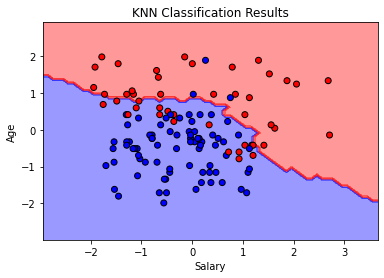

```python
# your code here
import matplotlib.pyplot as plt
from matplotlib.colors import ListedColormap

#feature values
x_min, x_max = X_test_scaled[:, 0].min() - 1, X_test_scaled[:, 0].max() + 1
y_min, y_max = X_test_scaled[:, 1].min() - 1, X_test_scaled[:, 1].max() + 1
xx, yy = np.meshgrid(np.arange(x_min, x_max, 0.1),
                     np.arange(y_min, y_max, 0.1))

#predictions
Z = classifier.predict(np.c_[xx.ravel(), yy.ravel()])
Z = Z.reshape(xx.shape)

plt.contourf(xx, yy, Z, alpha=0.4, cmap=ListedColormap(('blue', 'red')))

plt.scatter(X_test_scaled[:, 0], X_test_scaled[:, 1], c=y_test, cmap=ListedColormap(('blue', 'red')), edgecolors='k')

plt.xlabel('Salary')
plt.ylabel('Age')
plt.title('KNN Classification Results')
plt.show()
```